# tingverse_vignette

Cole Nawrocki

2023-07-21

```
library(tingverse)
library(tidyverse)
library(org.Hs.eg.db)
library(clusterProfiler)
library(parallel)
library(ggrepel)
library(knitr)
```

## Read in Example Data

This is old data from a Nanostring GeoMx experiment. `geom` is a normalized counts table. `metadata` is the meta data for each AOI in the experiment. scRNA-seq data could be used as well. You’ll need to use your own data.

```r
geom <- read.delim("/Users/cnawrocki/Library/CloudStorage/OneDrive-UniversityofVirginia/Ting Lab/Summer 2022/COLE/HCC/GeoMx/Data/qNormCounts.tsv")
metadata <- read.csv("/Users/cnawrocki/Library/CloudStorage/OneDrive-UniversityofVirginia/Ting Lab/Summer 2022/COLE/HCC/GeoMx/Data/meta_small.csv")

# Some basic manipulations to make the data files compatible.
colnames(geom) <- substr(colnames(geom),14,23)
metadata$Sample_ID_short<-gsub('-','.',metadata$Sample_ID_short)
geom <- geom[,colnames(geom) %in% metadata$Sample_ID_short]
rownames(metadata)<-metadata$Sample_ID_short
metadata <- metadata[metadata$Sample_ID_short %in% colnames(geom),]
```

## Differential Expression

Use the `differential.expression()` function first. Then, use the `volcano.plot()` function to visualize the results. FUse `?differential.expression` and `?volcano.plot` to view documentation.

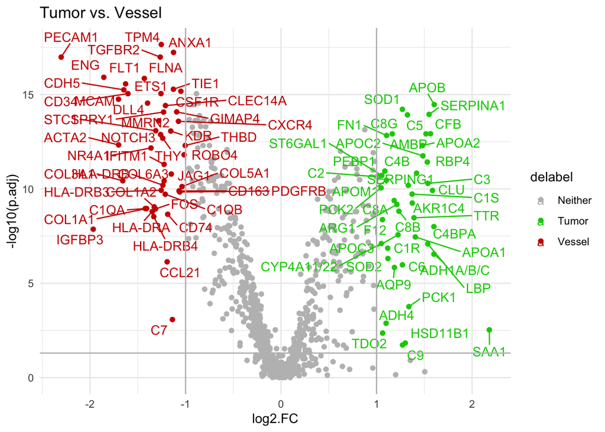

```r
DEA <- differential.expression(counts.table = geom,meta.data = metadata,meta.feature = "Tissue_Type",value.1 = "Tumor",value.2 = "Vessel",test = "wilcox")

volcano.plot(DEA,color.vals = c("green3","grey","red3"))
```

## GSEA

`?easy.gsea` will show documentation.

```r
GSEA_obj <- easy.gsea(DEA,order.stat = "log2.FC",ontology = "BP",organism = "human")
```

```
## preparing geneSet collections...
```

```
## GSEA analysis...
```

```
## leading edge analysis...
```

```
## done...
```

```r
# Viewing the results
kable(head(as.data.frame(GSEA_obj)),format = 'markdown')
```

|  | ID | Description | setSize | enrichmentScore | NES | pvalue | p.adjust | qvalue | rank | leading_edge | core_enrichment |
| --- | --- | --- | --- | --- | --- | --- | --- | --- | --- | --- | --- |
| GO:0044281 | GO:0044281 | small molecule metabolic process | 172 | 0.5312476 | 2.257112 | 0 | 0 | 0 | 159 | tags=39%, list=17%, signal=40% | APOB/C3/RBP4/APOC2/APOA2/APOA1/TTR/AKR1C4/PCK1/SOD1/APOC3/AR…… |
| GO:0016477 | GO:0016477 | cell migration | 217 | -0.5171173 | -2.163200 | 0 | 0 | 0 | 189 | tags=40%, list=20%, signal=41% | PPP3CA/CXCL6/TNF/ITGA6/IL17RA/SNAI2/S100A8/EPHA2/LAMA5/KRT5/…… |
| GO:0001568 | GO:0001568 | blood vessel development | 133 | -0.5729282 | -2.241643 | 0 | 0 | 0 | 141 | tags=37%, list=15%, signal=36% | TNFSF12/FZD4/SPRED1/ADM/ITGA5/NGFR/PKM/HGF/MFGE8/KLF4/THBS1/…… |
| GO:0048870 | GO:0048870 | cell motility | 226 | -0.4949787 | -2.082176 | 0 | 0 | 0 | 189 | tags=38%, list=20%, signal=40% | PPP3CA/CXCL6/TNF/ITGA6/IL17RA/SNAI2/S100A8/EPHA2/LAMA5/KRT5/…… |
| GO:0007166 | GO:0007166 | cell surface receptor signaling pathway | 380 | -0.4346784 | -1.910603 | 0 | 0 | 0 | 220 | tags=33%, list=23%, signal=42% | TNFAIP3/CD3D/WNT3/NUMBL/LYN/HIF1A/PRKCD/SH2B2/FZD6/CSF1/CXCL…… |
| GO:0001944 | GO:0001944 | vasculature development | 139 | -0.5565821 | -2.196147 | 0 | 0 | 0 | 141 | tags=35%, list=15%, signal=35% | TNFSF12/FZD4/SPRED1/ADM/ITGA5/NGFR/PKM/HGF/MFGE8/KLF4/THBS1/…… |

#### Looking at a Specific Gene Set

We can subset for only gene sets with 50 or more genes in them. Then, we can output the GSEA plot for the gene set with the highest enrichment score. `gseaplot` is a `ClusterProfiler` function.

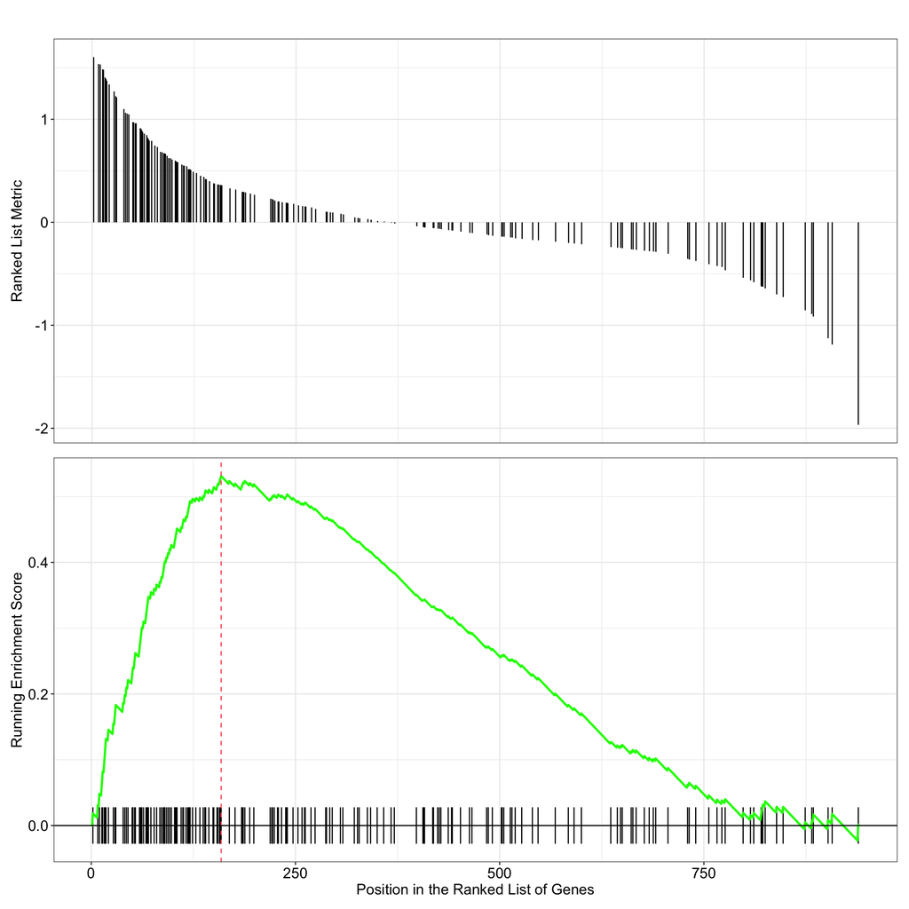

```r
results_oi <- GSEA_obj@result[order(GSEA_obj@result$enrichmentScore,decreasing = T) & GSEA_obj@result$setSize > 50,]

gseaplot(GSEA_obj,geneSetID = results_oi$ID[1])
```

#### Dotplot Based on Our Results

`dotplot` is a `ClusterProfiler` function. Here, we will look at the top 50 gene sets and separate based on if they are activated or deactivated.

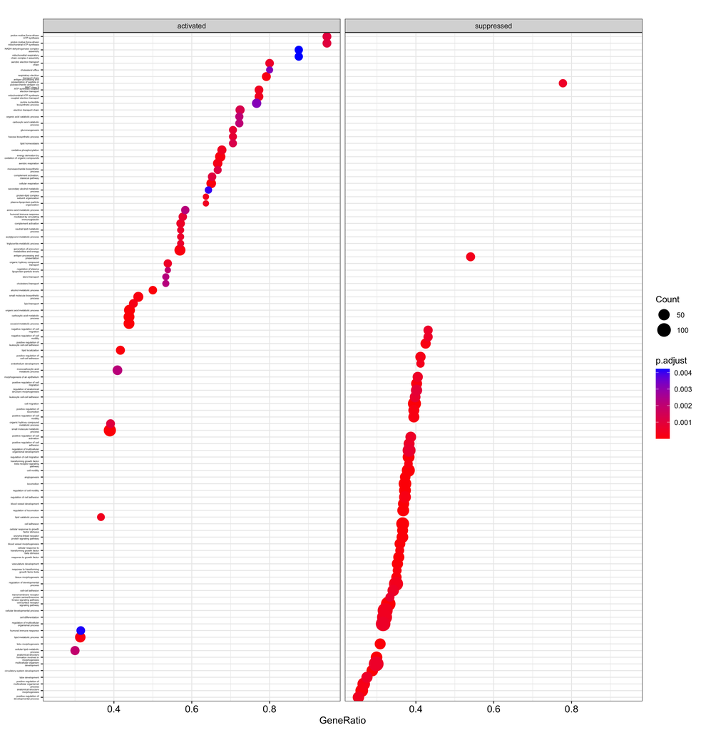

```r
dotplot(GSEA_obj,showCategory=50,split=".sign") + facet_grid(.~.sign) + theme(axis.text.y = element_text(size = 3))
```

#### Heatplot Based on Our Results

`heatplot` is a `ClusterProfiler` function. Here, we will look at the top 50 gene sets and visualize the LFC for each gene.

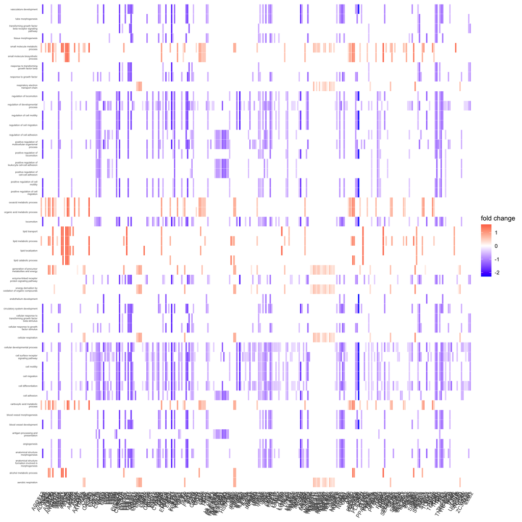

```r
heatplot(GSEA_obj,showCategory = 50,foldChange=GSEA_obj@geneList) + theme(axis.text.y = element_text(size = 4))
```

## Enrichment Analysis and Barplot

If we do not want to look at GSEA results, we can utilize this tool. We can look at all genes with a p.adj that is significant, run the analysis on them, then visualize the top 30 gene sets.

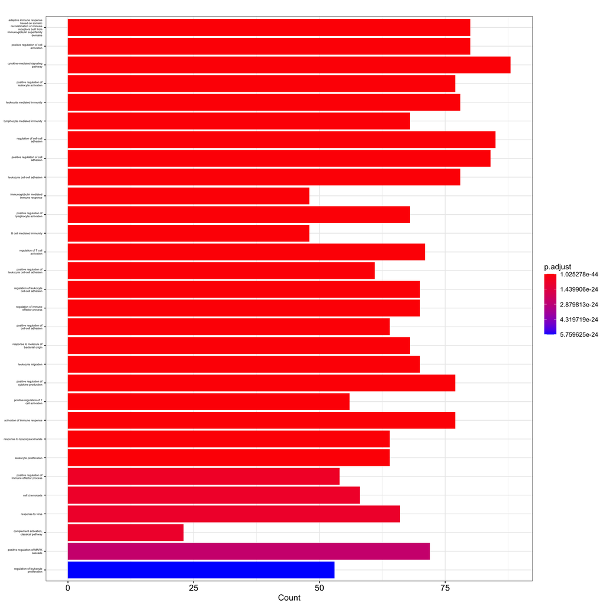

```r
genes_oi <- rownames(DEA[DEA$p.adj < 0.05,])
EA_obj <- enrichGO(gene = genes_oi,OrgDb = "org.Hs.eg.db",keyType = "SYMBOL",ont = "BP")
barplot(EA_obj, showCategory = 30) + theme(axis.text.y = element_text(size = 4))
```